# SORCS2_Genetics

SteveYounkin

October 21, 2015

## Analysis Plan

We will pursue a simple, straightforward analysis of our SORCS2 genotypes using a robust, R-based reproducible research approach. This will (i) provide a single document that gives us a complete account of our genetic analysis of SORCS2 and (ii) familiarize us with a scalable, cutting-edge approach that is capable of handling far more complicated analyses on large datasets.

We will keep all of our work in one R Markdown document: SOCS2_Genetics.Rmd.

To communicate with one another as we build this document, we will use the SORCS2 repository in my github account (https://github.com/StevenGYounkin/SORCS2), and we will all use git (GitHub gui) for version control.

All files used or generated by SORCS2_Genetics.Rmd will be in this SORCS2 repo.

Joseph will take responsiblity for providing whatever help may be needed for each of us to interact effectively with one another on GitHub to produce a final document.

Our goal, which we may or may not achieve, will be to complete a “publication ready”" PLoS ONE manuscript by Monday, November 16.

### What each participant needs:

1. RStudio installed
2. GitHub installed
3. Local clone of the repo at https://github.com/StevenGYounkin/SORCS2
   - SORCS2_Genetics.Rmd, the file we are generating together, is in this repo
     - All files used or generated by SORCS2_Genetics.Rmd are in this repo
4. R packages installed
   - dplyr
   - data.table
5. PLINK installed and set up so it can be called by R with system(“plink……”)

### Useful documentation:

1. GitHub
   - https://training.github.com/kit/downloads/github-git-cheat-sheet
2. R Markdown
   - https://www.rstudio.com/wp-content/uploads/2015/02/rmarkdown-cheatsheet.pdf
3. dplyr and tidyr
   - https://www.rstudio.com/wp-content/uploads/2015/02/data-wrangling-cheatsheet.pdf
4. PLINK
   - http://pngu.mgh.harvard.edu/~purcell/plink/

### Responsibility for Specific Analysis Steps:

1. Provide existing SORCS2 dataset(s) and initate analyses calling PLINK from R
   - Steve has done this with Joseph’s help
2. Short-term goals for Steve’s R script
   - Read in Joseph’s current ADSP dataset and generate PLINK files
   - Read in and display PLINK files that are being generated
   - Generate function(s) creating PLINK files from input dataset(s)
   - Figure our how best to display manuscript text and write the introduction.
3. Download ADSP SORCS2 dataset
   - Joseph has downloaded dataset for 1000 sampleswill do this as the data become available (3000 samples should soon be ready)
4. Create Figure 1 showing a SORCS2 gene diagram with information on SNP location etc.
   - Ben and Leonie are working on this.

### Steve’s Content

#### Read in and Analyze Ydb SORCS2 dataset

The data we have on the 4 common SORCS2 missense variants in the Younkin database (YdB) was captured using the following query:

SELECT TOP (100) PERCENT Younkin.dbo.Subject.SubKey, Younkin.dbo.Subject.SubjectIDType, Younkin.dbo.Subject.SubjectIDValue, Younkin.dbo.Subject.Series, Younkin.dbo.Subject.Dx, Younkin.dbo.Subject.ApoE, Younkin.dbo.Subject.DxAge, Younkin.dbo.Subject.Gend, Younkin.dbo.Variant.VariantID, Younkin.dbo.Variant.VariantName, Younkin.dbo.VariantDataAll.Call, Younkin.dbo.VariantDataAll.BestCall, Younkin.dbo.Variant_New.chr, Younkin.dbo.Variant_New.position, Younkin.dbo.Variant_New.rs FROM Younkin.dbo.VariantDataAll INNER JOIN Younkin.dbo.Variant ON Younkin.dbo.VariantDataAll.VariantID = Younkin.dbo.Variant.VariantID INNER JOIN Younkin.dbo.Subject ON Younkin.dbo.VariantDataAll.SKey = Younkin.dbo.Subject.SubKey INNER JOIN Younkin.dbo.Variant_New ON Younkin.dbo.VariantDataAll.VariantID = Younkin.dbo.Variant_New.VariantID WHERE (Younkin.dbo.Variant.VariantID = 2069 OR Younkin.dbo.Variant.VariantID = 2070 OR Younkin.dbo.Variant.VariantID = 2072 OR Younkin.dbo.Variant.VariantID = 2073) ORDER BY Younkin.dbo.Variant.VariantID

The results of this query were copied into SORCS2_Ydb.csv

```r
        #Read in data on 4 common SORCS2 missense variants in the Younkin database
SORCS2_YdB <- read.csv("SORCS2_Ydb.csv", stringsAsFactors = FALSE)
str(SORCS2_YdB)
```

```
## 'data.frame':    40384 obs. of  15 variables:
##  $ SubKey        : int  14642 14644 14649 14651 14658 14660 14667 14674 14676 14683 ...
##  $ SubjectIDType : chr  "RochesterPTNUM" "RochesterPTNUM" "RochesterPTNUM" "RochesterPTNUM" ...
##  $ SubjectIDValue: chr  "6040" "4588" "5174" "5473" ...
##  $ Series        : chr  "RS" "RS" "RS" "RS" ...
##  $ Dx            : chr  "CON" "NULL" "CON" "CON" ...
##  $ ApoE          : chr  "34" "23" "33" "24" ...
##  $ DxAge         : chr  "76" "75.38" "75" "85" ...
##  $ Gend          : chr  "M" "M" "M" "M" ...
##  $ VariantID     : int  2069 2069 2069 2069 2069 2069 2069 2069 2069 2069 ...
##  $ VariantName   : chr  "SORCS2_rs6816604_CT" "SORCS2_rs6816604_CT" "SORCS2_rs6816604_CT" "SORCS2_rs6816604_CT" ...
##  $ Call          : int  11 11 11 11 11 11 11 11 11 11 ...
##  $ BestCall      : int  1 1 1 1 1 1 1 1 1 1 ...
##  $ chr           : int  4 4 4 4 4 4 4 4 4 4 ...
##  $ position      : int  7716932 7716932 7716932 7716932 7716932 7716932 7716932 7716932 7716932 7716932 ...
##  $ rs            : chr  "rs6816604" "rs6816604" "rs6816604" "rs6816604" ...
```

```r
        #Filter, using dplyr package, to include only subjects with:
        #Dx = AD or CON, Gend = M or F, ApoE = 22,23,24,33,34,or 44
        #Series = JS,SibPair_White,RS,AUT,Indiana,NW, DxAge >= 65, BestCall = 1
        #Age (at diagnosis for AD/at entry for CON) of 65 or over
library(dplyr)
dx <- c("AD","CON")
sex <- c("M","F")
apoe <- c(22,23,24,33,34,44)
series <- c("JS", "RS", "AUT", "Indiana", "SibPair_White", "NW")
SORCS2 <- filter(SORCS2_YdB, Dx %in% dx, Gend %in% sex, ApoE %in% apoe, Series %in% series, BestCall == 1)
SORCS2 <- mutate(SORCS2,Age=as.numeric(DxAge))
```

```r
SORCS2 <- filter (SORCS2, Age >= 65)

        #Create PLINK map file
library(data.table)
map <- select(SORCS2,chr, rs, position)
map <- mutate(map,morgans=0)
map <- rename(map, bp=position)
map <- select(map,chr,rs,morgans,bp)
map <- distinct(map)
print(map)
```

```
##   chr         rs morgans      bp
## 1   4  rs6816604       0 7716932
## 2   4 rs35935435       0 7666180
## 3   4 rs16840892       0 7716061
## 4   4 rs34058821       0 7666160
```

```r
write.table(map,"SORCS2.map",sep='\t',quote=FALSE,row.names=F,col.names=F)
SORCS2map=read.table("SORCS2.map", header = F)
print(SORCS2map,row.names=F,col.names=F)
```

```
##  V1         V2 V3      V4
##   4  rs6816604  0 7716932
##   4 rs35935435  0 7666180
##   4 rs16840892  0 7716061
##   4 rs34058821  0 7666160
```

```r
        #Create variables for PLINK fam, cov, and lgen files
SORCS2 <- mutate(SORCS2, AFF=99, A1=99, A2=99, APOE4dose=99, APOE2dose=99, SEX=99, JS=0, RS=0, AUT=0, NCRAD=0, NW=0, FID=0, IID=SubKey, PID=0, MID=0)

SORCS2[SORCS2$Dx == "AD",][, "AFF"] <- 2
SORCS2[SORCS2$Dx == "CON",][, "AFF"] <- 1

SORCS2[SORCS2$Call == 11,][, "A1"] <- 1
SORCS2[SORCS2$Call == 12,][, "A1"] <- 1
SORCS2[SORCS2$Call == 22,][, "A1"] <- 2

SORCS2[SORCS2$Call == 11,][, "A2"] <- 1
SORCS2[SORCS2$Call == 12,][, "A2"] <- 2
SORCS2[SORCS2$Call == 22,][, "A2"] <- 2

SORCS2[SORCS2$Gend == "M",][, "SEX"] <- 1
SORCS2[SORCS2$Gend == "F",][, "SEX"] <- 2

SORCS2[SORCS2$ApoE == 22,][, "APOE4dose"] <- 0
SORCS2[SORCS2$ApoE == 23,][, "APOE4dose"] <- 0
SORCS2[SORCS2$ApoE == 24,][, "APOE4dose"] <- 1
SORCS2[SORCS2$ApoE == 33,][, "APOE4dose"] <- 0
SORCS2[SORCS2$ApoE == 34,][, "APOE4dose"] <- 1
SORCS2[SORCS2$ApoE == 44,][, "APOE4dose"] <- 2

SORCS2[SORCS2$ApoE == 22,][, "APOE2dose"] <- 2
SORCS2[SORCS2$ApoE == 23,][, "APOE2dose"] <- 1
SORCS2[SORCS2$ApoE == 24,][, "APOE2dose"] <- 1
SORCS2[SORCS2$ApoE == 33,][, "APOE2dose"] <- 0
SORCS2[SORCS2$ApoE == 34,][, "APOE2dose"] <- 0
SORCS2[SORCS2$ApoE == 44,][, "APOE2dose"] <- 0

SORCS2[SORCS2$Series == "JS",][, "JS"] <- 1
SORCS2[SORCS2$Series == "SibPair_White",][, "JS"] <- 1
SORCS2[SORCS2$Series == "RS",][, "RS"] <- 1
SORCS2[SORCS2$Series == "AUT",][, "AUT"] <- 1
SORCS2[SORCS2$Series == "Indiana",][, "NCRAD"] <- 1
SORCS2[SORCS2$Series == "NW",][, "NW"] <- 1

y <- SORCS2 %>% filter(rs=="rs6816604",JS==1) %>% group_by(rs,Dx,A1,A2) %>% summarize(n=n())
print(y)
```

```
## Source: local data frame [6 x 5]
## Groups: rs, Dx, A1 [?]
##
##          rs    Dx    A1    A2     n
##       (chr) (chr) (dbl) (dbl) (int)
## 1 rs6816604    AD     1     1   829
## 2 rs6816604    AD     1     2    87
## 3 rs6816604    AD     2     2     2
## 4 rs6816604   CON     1     1  1146
## 5 rs6816604   CON     1     2   120
## 6 rs6816604   CON     2     2     6
```

```r
        #Create PLINK fam file
fam <- select(SORCS2,FID,IID,PID,MID,SEX,AFF)
fam <- distinct(fam)
str(fam); head(fam); tail(fam)
```

```
## 'data.frame':    7727 obs. of  6 variables:
##  $ FID: num  0 0 0 0 0 0 0 0 0 0 ...
##  $ IID: int  14642 14649 14651 14658 14660 14683 14685 14699 14708 14710 ...
##  $ PID: num  0 0 0 0 0 0 0 0 0 0 ...
##  $ MID: num  0 0 0 0 0 0 0 0 0 0 ...
##  $ SEX: num  1 1 1 1 2 2 2 1 2 1 ...
##  $ AFF: num  1 1 1 1 1 1 1 1 1 1 ...
```

```
##   FID   IID PID MID SEX AFF
## 1   0 14642   0   0   1   1
## 2   0 14649   0   0   1   1
## 3   0 14651   0   0   1   1
## 4   0 14658   0   0   1   1
## 5   0 14660   0   0   2   1
## 6   0 14683   0   0   2   1
```

```
##      FID   IID PID MID SEX AFF
## 7722   0 80628   0   0   2   1
## 7723   0 17300   0   0   2   2
## 7724   0  2560   0   0   2   2
## 7725   0   917   0   0   2   1
## 7726   0 58450   0   0   2   2
## 7727   0  2205   0   0   2   2
```

```r
write.table(fam,"SORCS2.fam",sep='\t',quote=FALSE,row.names=F,col.names=F)
SORCS2fam=read.table("SORCS2.fam", header = F)
str(SORCS2fam);head(SORCS2fam);tail(SORCS2fam)
```

```
## 'data.frame':    7727 obs. of  6 variables:
##  $ V1: int  0 0 0 0 0 0 0 0 0 0 ...
##  $ V2: int  14642 14649 14651 14658 14660 14683 14685 14699 14708 14710 ...
##  $ V3: int  0 0 0 0 0 0 0 0 0 0 ...
##  $ V4: int  0 0 0 0 0 0 0 0 0 0 ...
##  $ V5: int  1 1 1 1 2 2 2 1 2 1 ...
##  $ V6: int  1 1 1 1 1 1 1 1 1 1 ...
```

```
##   V1    V2 V3 V4 V5 V6
## 1  0 14642  0  0  1  1
## 2  0 14649  0  0  1  1
## 3  0 14651  0  0  1  1
## 4  0 14658  0  0  1  1
## 5  0 14660  0  0  2  1
## 6  0 14683  0  0  2  1
```

```
##      V1    V2 V3 V4 V5 V6
## 7722  0 80628  0  0  2  1
## 7723  0 17300  0  0  2  2
## 7724  0  2560  0  0  2  2
## 7725  0   917  0  0  2  1
## 7726  0 58450  0  0  2  2
## 7727  0  2205  0  0  2  2
```

```r
        #Create PLINK cov file;
        #Not sure why, but errors sometimes occurred in r when using "SORCS2.cov"" as output using write.table
        #So I used "SORCS2cov.txt" thereby avoiding this problem
cov <- select(SORCS2,FID,IID,JS,RS,AUT,NCRAD,NW,SEX,Age,APOE4dose,APOE2dose)
cov <- distinct(cov)
str(cov)
```

```
## 'data.frame':    7727 obs. of  11 variables:
##  $ FID      : num  0 0 0 0 0 0 0 0 0 0 ...
##  $ IID      : int  14642 14649 14651 14658 14660 14683 14685 14699 14708 14710 ...
##  $ JS       : num  0 0 0 0 0 0 0 0 0 0 ...
##  $ RS       : num  1 1 1 1 1 1 1 1 1 1 ...
##  $ AUT      : num  0 0 0 0 0 0 0 0 0 0 ...
##  $ NCRAD    : num  0 0 0 0 0 0 0 0 0 0 ...
##  $ NW       : num  0 0 0 0 0 0 0 0 0 0 ...
##  $ SEX      : num  1 1 1 1 2 2 2 1 2 1 ...
##  $ Age      : num  76 75 85 90 78 76 97 93 84 88 ...
##  $ APOE4dose: num  1 0 1 1 0 1 1 1 0 0 ...
##  $ APOE2dose: num  0 0 1 0 0 0 0 0 0 0 ...
```

```r
write.table(cov,"SORCS2cov.txt",sep='\t',quote=FALSE,row.names=F,col.names=T)
SORCS2cov=read.table("SORCS2cov.txt", header = T)
str(SORCS2cov);head(SORCS2cov); tail(SORCS2cov)
```

```
## 'data.frame':    7727 obs. of  11 variables:
##  $ FID      : int  0 0 0 0 0 0 0 0 0 0 ...
##  $ IID      : int  14642 14649 14651 14658 14660 14683 14685 14699 14708 14710 ...
##  $ JS       : int  0 0 0 0 0 0 0 0 0 0 ...
##  $ RS       : int  1 1 1 1 1 1 1 1 1 1 ...
##  $ AUT      : int  0 0 0 0 0 0 0 0 0 0 ...
##  $ NCRAD    : int  0 0 0 0 0 0 0 0 0 0 ...
##  $ NW       : int  0 0 0 0 0 0 0 0 0 0 ...
##  $ SEX      : int  1 1 1 1 2 2 2 1 2 1 ...
##  $ Age      : num  76 75 85 90 78 76 97 93 84 88 ...
##  $ APOE4dose: int  1 0 1 1 0 1 1 1 0 0 ...
##  $ APOE2dose: int  0 0 1 0 0 0 0 0 0 0 ...
```

```
##   FID   IID JS RS AUT NCRAD NW SEX Age APOE4dose APOE2dose
## 1   0 14642  0  1   0     0  0   1  76         1         0
## 2   0 14649  0  1   0     0  0   1  75         0         0
## 3   0 14651  0  1   0     0  0   1  85         1         1
## 4   0 14658  0  1   0     0  0   1  90         1         0
## 5   0 14660  0  1   0     0  0   2  78         0         0
## 6   0 14683  0  1   0     0  0   2  76         1         0
```

```
##      FID   IID JS RS AUT NCRAD NW SEX Age APOE4dose APOE2dose
## 7722   0 80628  1  0   0     0  0   2  90         0         0
## 7723   0 17300  0  0   1     0  0   2  82         0         0
## 7724   0  2560  0  1   0     0  0   2  94         0         0
## 7725   0   917  1  0   0     0  0   2  70         0         0
## 7726   0 58450  0  0   0     1  0   2  70         2         0
## 7727   0  2205  0  1   0     0  0   2  96         0         0
```

```r
        #Create PLINK lgen file
lgen <- select(SORCS2,FID,IID,rs,A1,A2)
str(lgen)
```

```
## 'data.frame':    29638 obs. of  5 variables:
##  $ FID: num  0 0 0 0 0 0 0 0 0 0 ...
##  $ IID: int  14642 14649 14651 14658 14660 14683 14685 14699 14708 14710 ...
##  $ rs : chr  "rs6816604" "rs6816604" "rs6816604" "rs6816604" ...
##  $ A1 : num  1 1 1 1 1 1 1 1 1 1 ...
##  $ A2 : num  1 1 1 1 1 1 1 1 1 1 ...
```

```r
write.table(lgen,"SORCS2.lgen",sep='\t',quote=FALSE,row.names=F,col.names=F)
SORCS2lgen=read.table("SORCS2.lgen", header = F)
str(SORCS2lgen)
```

```
## 'data.frame':    29638 obs. of  5 variables:
##  $ V1: int  0 0 0 0 0 0 0 0 0 0 ...
##  $ V2: int  14642 14649 14651 14658 14660 14683 14685 14699 14708 14710 ...
##  $ V3: Factor w/ 4 levels "rs16840892","rs34058821",..: 4 4 4 4 4 4 4 4 4 4 ...
##  $ V4: int  1 1 1 1 1 1 1 1 1 1 ...
##  $ V5: int  1 1 1 1 1 1 1 1 1 1 ...
```

```r
        #PLINK --assoc: analyzes standard case/control (allelic) association with LOAD, no covariates
system("plink --lfile SORCS2 --assoc --counts --out SORCS2assoc")
SORCS2assoc <- read.table("SORCS2assoc.assoc", header = T)
str(SORCS2assoc);head(SORCS2assoc);tail(SORCS2assoc)
```

```
## 'data.frame':    4 obs. of  10 variables:
##  $ CHR  : int  4 4 4 4
##  $ SNP  : Factor w/ 4 levels "rs16840892","rs34058821",..: 2 3 1 4
##  $ BP   : int  7666160 7666180 7716061 7716932
##  $ A1   : int  2 2 2 2
##  $ C_A  : int  311 137 71 389
##  $ C_U  : int  448 135 91 465
##  $ A2   : int  1 1 1 1
##  $ CHISQ: num  10.96 2.398 0.562 0.13
##  $ P    : num  0.00093 0.1215 0.4536 0.718
##  $ OR   : num  0.778 1.208 0.888 0.975
```

```
##   CHR        SNP      BP A1 C_A C_U A2   CHISQ         P     OR
## 1   4 rs34058821 7666160  2 311 448  1 10.9600 0.0009302 0.7785
## 2   4 rs35935435 7666180  2 137 135  1  2.3980 0.1215000 1.2080
## 3   4 rs16840892 7716061  2  71  91  1  0.5616 0.4536000 0.8876
## 4   4  rs6816604 7716932  2 389 465  1  0.1304 0.7180000 0.9748
```

```
##   CHR        SNP      BP A1 C_A C_U A2   CHISQ         P     OR
## 1   4 rs34058821 7666160  2 311 448  1 10.9600 0.0009302 0.7785
## 2   4 rs35935435 7666180  2 137 135  1  2.3980 0.1215000 1.2080
## 3   4 rs16840892 7716061  2  71  91  1  0.5616 0.4536000 0.8876
## 4   4  rs6816604 7716932  2 389 465  1  0.1304 0.7180000 0.9748
```

```r
        #PLINK --assoc: analyzes association by logistic regression using an additive model with with covariates
system("plink --lfile SORCS2 --logistic --ci 0.95 --covar SORCS2cov.txt --covar-name RS,AUT,NCRAD,NW,SEX,Age,APOE4dose,APOE2dose --out SORCS2logAllCov")

system("plink --lfile SORCS2 --hap-window 4 --hap-logistic --ci 0.95 --covar SORCS2cov.txt --covar-name RS-APOE2dose --mhf 0.005 --out SORCS2haplogAllCov")
system("plink --lfile SORCS2 --hap-window 4 --hap-logistic --ci 0.95 --covar SORCS2cov.txt --covar-name RS-APOE2dose --mhf 0.005 --hap-omnibus --out SORCS2haplogAllCovOmni")
system("plink --lfile SORCS2 --logistic --ci 0.95 --covar SORCS2cov.txt --covar-name APOE4dose,APOE2dose --out SORCS2logAPOECov")
list.files()
```

```
##  [1] "SORCS2.fam"
##  [2] "SORCS2.lgen"
##  [3] "SORCS2.map"
##  [4] "SORCS2_flat_file.txt"
##  [5] "SORCS2_Genetics.html"
##  [6] "SORCS2_Genetics.Rmd"
##  [7] "SORCS2_Ydb.csv"
##  [8] "SORCS2assoc.assoc"
##  [9] "SORCS2assoc.log"
## [10] "SORCS2cov.txt"
## [11] "SORCS2haplogAllCov.assoc.hap.logistic"
## [12] "SORCS2haplogAllCov.log"
## [13] "SORCS2haplogAllCovOmni.assoc.hap.logistic"
## [14] "SORCS2haplogAllCovOmni.log"
## [15] "SORCS2logAllCov.assoc.logistic"
## [16] "SORCS2logAllCov.log"
## [17] "SORCS2logAPOECov.assoc.logistic"
## [18] "SORCS2logAPOECov.log"
## [19] "SORCS2logAssoc.assoc"
## [20] "SORCS2logAssoc.log"
```

#### Read in and Analyze ADSP SORCS2 dataset

```r
        #Read in data on 4 common SORCS2 missense variants in the ADSP database        #
SORCS2_ADSP <- read.table("SORCS2_flat_file.txt", header = T)
str(SORCS2_ADSP);head(SORCS2_ADSP);tail(SORCS2_ADSP)
```

```
## 'data.frame':    25000 obs. of  16 variables:
##  $ Subject_ID  : Factor w/ 1000 levels "SRR1198015","SRR1198016",..: 1 2 3 4 5 6 7 8 9 10 ...
##  $ Series      : Factor w/ 1 level "ADSP": 1 1 1 1 1 1 1 1 1 1 ...
##  $ Sex         : int  0 0 1 0 0 0 1 1 1 1 ...
##  $ Age         : num  64 71 85 87.3 82.2 ...
##  $ Case.control: int  2 2 1 1 1 1 1 1 0 0 ...
##  $ APOE        : int  34 34 23 33 33 33 34 33 33 33 ...
##  $ Gene        : Factor w/ 1 level "SORCS2": 1 1 1 1 1 1 1 1 1 1 ...
##  $ SNP_ID      : Factor w/ 19 levels ".","rs144615557",..: 17 17 17 17 17 17 17 17 17 17 ...
##  $ CHR         : Factor w/ 1 level "chr4": 1 1 1 1 1 1 1 1 1 1 ...
##  $ Position    : int  7640109 7640109 7640109 7640109 7640109 7640109 7640109 7640109 7640109 7640109 ...
##  $ Ref         : Factor w/ 4 levels "A","C","G","T": 3 3 3 3 3 3 3 3 3 3 ...
##  $ Alt         : Factor w/ 4 levels "A","C","G","T": 1 1 1 1 1 1 1 1 1 1 ...
##  $ Codon       : Factor w/ 17 levels "aAg/aGg","aCc/aAc",..: 13 13 13 13 13 13 13 13 13 13 ...
##  $ AA          : Factor w/ 25 levels "A1039P","A1040P",..: 3 3 3 3 3 3 3 3 3 3 ...
##  $ Call        : int  11 11 11 11 11 11 11 11 11 11 ...
##  $ Genotype    : Factor w/ 4 levels "./.","0/0","0/1",..: 2 2 2 2 2 2 2 2 2 2 ...
```

```
##   Subject_ID Series Sex      Age Case.control APOE   Gene      SNP_ID  CHR
## 1 SRR1198015   ADSP   0 64.00000            2   34 SORCS2 rs527549780 chr4
## 2 SRR1198016   ADSP   0 71.00000            2   34 SORCS2 rs527549780 chr4
## 3 SRR1267825   ADSP   1 84.98015            1   23 SORCS2 rs527549780 chr4
## 4 SRR1267826   ADSP   0 87.29911            1   33 SORCS2 rs527549780 chr4
## 5 SRR1267827   ADSP   0 82.17659            1   33 SORCS2 rs527549780 chr4
## 6 SRR1267828   ADSP   0 90.81999            1   33 SORCS2 rs527549780 chr4
##   Position Ref Alt   Codon    AA Call Genotype
## 1  7640109   G   A Gca/Aca A235T   11      0/0
## 2  7640109   G   A Gca/Aca A235T   11      0/0
## 3  7640109   G   A Gca/Aca A235T   11      0/0
## 4  7640109   G   A Gca/Aca A235T   11      0/0
## 5  7640109   G   A Gca/Aca A235T   11      0/0
## 6  7640109   G   A Gca/Aca A235T   11      0/0
```

```
##       Subject_ID Series Sex Age Case.control APOE   Gene      SNP_ID  CHR
## 24995 SRR1578802   ADSP   1  80            1   33 SORCS2 rs199714956 chr4
## 24996 SRR1578822   ADSP   0  84            0   33 SORCS2 rs199714956 chr4
## 24997 SRR1578829   ADSP   1  70            1   34 SORCS2 rs199714956 chr4
## 24998 SRR1578839   ADSP   0  65            1   33 SORCS2 rs199714956 chr4
## 24999 SRR1578847   ADSP   1  65            1   33 SORCS2 rs199714956 chr4
## 25000 SRR1578852   ADSP   1  63            1   34 SORCS2 rs199714956 chr4
##       Position Ref Alt   Codon     AA Call Genotype
## 24995  7735116   G   A cGg/cAg R1059Q   11      0/0
## 24996  7735116   G   A cGg/cAg R1059Q   11      0/0
## 24997  7735116   G   A cGg/cAg R1059Q   11      0/0
## 24998  7735116   G   A cGg/cAg R1059Q   11      0/0
## 24999  7735116   G   A cGg/cAg R1059Q   11      0/0
## 25000  7735116   G   A cGg/cAg R1059Q   11      0/0
```

### Ben and Leonie’s Content

First draft of gene diagram - exact positions and lengths of exons to be added.

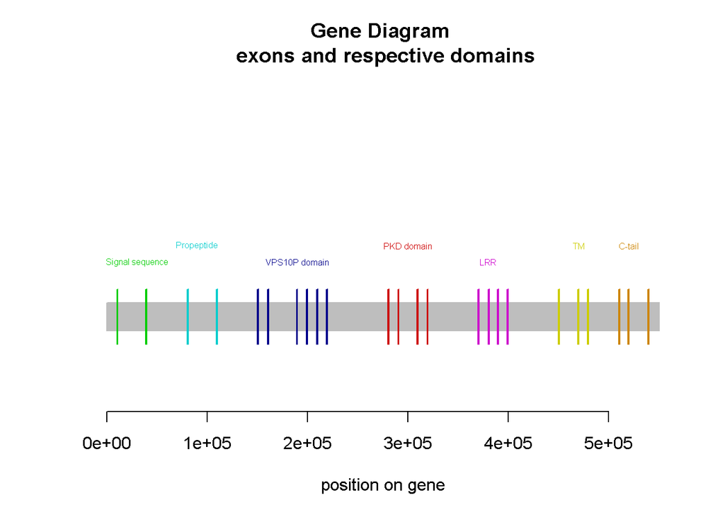

```r
# set up the plot
op <- par(bg = "white")
plot(c(0, 550230), c(-100, 450), main="Gene Diagram \n exons and respective domains", type= "n", xlab="position on gene", ylab="",yaxt='n',frame.plot=FALSE)
rect(0, 25, 550230, 75, col="grey", border="grey")

#exons and respective domains
##signal sequence
rect(10000, 0, 11000, 100, col="green", border="green3")
rect(39000, 0, 40000, 100, col="green", border="green3")
text(30000,150, labels= "Signal sequence",cex=0.5,col="green3")

##propeptide
rect(80000, 0, 81000, 100, col="cyan", border="cyan3")
rect(109000, 0, 110000, 100, col="cyan", border="cyan3")
text(90000,180, labels= "Propeptide",cex=0.5,col="cyan3")

##vps10p domain
rect(150000, 0, 151000, 100, col="blue", border="blue4")
rect(160000, 0, 161000, 100, col="blue", border="blue4")
rect(189000, 0, 190000, 100, col="blue", border="blue4")
rect(199000, 0, 200000, 100, col="blue", border="blue4")
rect(209000, 0, 210000, 100, col="blue", border="blue4")
rect(219000, 0, 220000, 100, col="blue", border="blue4")
text(190000,150, labels= "VPS10P domain",cex=0.5,col="blue4")

##pkd domain
rect(280000, 0, 281000, 100, col="red", border="red3")
rect(290000, 0, 291000, 100, col="red", border="red3")
rect(309000, 0, 310000, 100, col="red", border="red3")
rect(319000, 0, 320000, 100, col="red", border="red3")
text(300000,180, labels= "PKD domain",cex=0.5,col="red3")

##lrr
rect(370000, 0, 371000, 100, col="magenta", border="magenta3")
rect(380000, 0, 381000, 100, col="magenta", border="magenta3")
rect(389000, 0, 390000, 100, col="magenta", border="magenta3")
rect(399000, 0, 400000, 100, col="magenta", border="magenta3")
text(380000,150, labels= "LRR",cex=0.5,col="magenta3")

##tm
rect(450000, 0, 451000, 100, col="yellow", border="yellow3")
rect(469000, 0, 470000, 100, col="yellow", border="yellow3")
rect(479000, 0, 480000, 100, col="yellow", border="yellow3")
text(470000,180, labels= "TM",cex=0.5,col="yellow3")

##c-tail
rect(510000, 0, 511000, 100, col="orange", border="orange3")
rect(519000, 0, 520000, 100, col="orange", border="orange3")
rect(539000, 0, 540000, 100, col="orange", border="orange3")
text(520000,180, labels= "C-tail",cex=0.5,col="orange3")
```